# REPORT ON ACTIVITY

Rishab Jain

19/08/2020

# Summarising the data

Loading the data

```r
library(readr)
activity <- read_csv("activity.csv")
head(activity)
```

```
## # A tibble: 6 x 3
##   steps date       interval
##   <dbl> <date>        <dbl>
## 1    NA 2012-10-01        0
## 2    NA 2012-10-01        5
## 3    NA 2012-10-01       10
## 4    NA 2012-10-01       15
## 5    NA 2012-10-01       20
## 6    NA 2012-10-01       25
```

```r
dim(activity)
```

```
## [1] 17568     3
```

```r
summary(activity)
```

```
##      steps             date               interval
##  Min.   :  0.00   Min.   :2012-10-01   Min.   :   0.0
##  1st Qu.:  0.00   1st Qu.:2012-10-16   1st Qu.: 588.8
##  Median :  0.00   Median :2012-10-31   Median :1177.5
##  Mean   : 37.38   Mean   :2012-10-31   Mean   :1177.5
##  3rd Qu.: 12.00   3rd Qu.:2012-11-15   3rd Qu.:1766.2
##  Max.   :806.00   Max.   :2012-11-30   Max.   :2355.0
##  NA's   :2304
```

# Date Modification

```r
activity$date <- as.Date(as.character(activity$date))
na <- is.na(activity$steps)
clean <- activity[!na,]
clean
```

```
## # A tibble: 15,264 x 3
##    steps date       interval
##    <dbl> <date>        <dbl>
##  1     0 2012-10-02        0
##  2     0 2012-10-02        5
##  3     0 2012-10-02       10
##  4     0 2012-10-02       15
##  5     0 2012-10-02       20
##  6     0 2012-10-02       25
##  7     0 2012-10-02       30
##  8     0 2012-10-02       35
##  9     0 2012-10-02       40
## 10     0 2012-10-02       45
## # ... with 15,254 more rows
```

# What is mean total number of steps taken per day?

# 1. Calculate the total number of steps taken per day?

```r
sumdata <- aggregate(activity$steps,by = list(activity$date),sum)
names(sumdata)[1] = "date"
names(sumdata)[2] = "totalstep"
head(sumdata,15)
```

```
##          date totalstep
## 1  2012-10-01        NA
## 2  2012-10-02       126
## 3  2012-10-03     11352
## 4  2012-10-04     12116
## 5  2012-10-05     13294
## 6  2012-10-06     15420
## 7  2012-10-07     11015
## 8  2012-10-08        NA
## 9  2012-10-09     12811
## 10 2012-10-10      9900
## 11 2012-10-11     10304
## 12 2012-10-12     17382
## 13 2012-10-13     12426
## 14 2012-10-14     15098
## 15 2012-10-15     10139
```

# 2. Histogram of the total number of steps taken each day

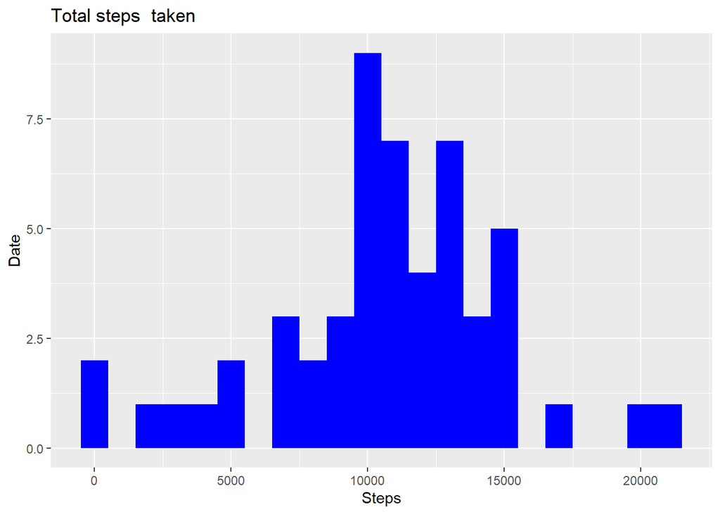

```r
library(ggplot2)
ggplot(sumdata,aes(x = totalstep))+ geom_histogram(fill = "blue",binwidth = 1000)+labs(title = "Total steps  taken",x = "Steps",y = "Date")
```

# 3. Calculated and reported the mean and median of the total number of steps taken per day

```r
mean(sumdata$totalstep,na.rm = TRUE)
```

```
## [1] 10766.19
```

```r
median(sumdata$totalstep,na.rm = TRUE)
```

```
## [1] 10765
```

# What is the average daily activity pattern?

# 1. Make a time series plot of the 5-minute interval (x-axis) and the average number of steps taken, averaged across all days (y-axis)

```r
nonNASubset <- activity[!na,]
MeanDataByInterval <- aggregate(nonNASubset$steps, by=list(nonNASubset$interval), mean)
```

# Set the column names

[figure not shown]

```r
names(MeanDataByInterval)[1] ="interval"
names(MeanDataByInterval)[2] ="steps"
ggplot(MeanDataByInterval, aes(x = interval, y=steps)) +
labs(title = "Sum of Steps by Interval", x = "interval", y = "steps")+
geom_line(color="red")
```

# 2. Which 5-minute interval, on average across all the days in the dataset, contains the maximum number of steps?

```r
maxInterval <- MeanDataByInterval[which.max(MeanDataByInterval$steps),]
maxInterval
```

```
##     interval    steps
## 104      835 206.1698
```

# Imputing missing values

1. Calculate and report the total number of missing values in the dataset (i.e. the total number of rows with NAs)

```r
missingvalue <- sum(na)
missingvalue
```

```
## [1] 2304
```

# A strategy for filling in all of the missing values in the dataset.

# Strategy: Use mean interval steps from Mean Steps for that interval.

3. Creating a new dataset that is equal to the original dataset but with the missing data filled in.

```r
activity2 <- activity
na2 <- activity2 [is.na(activity$steps),]
clean2 <-  activity2[is.na(activity2$steps),]
meandata <- aggregate(clean2$steps,by = list(clean2$interval),sum)
names(meandata)[1] <- "intervals"
names(meandata)[2] <- "steps"
missing <- is.na(activity2$steps)
meanvals <- tapply(clean$steps,clean$interval,mean,na.rm = TRUE,simplify = TRUE)
activity2$steps[missing] <- meanvals[as.character(activity2$interval[missing])]
sum(is.na(activity2))
```

```
## [1] 0
```

# 4a) Making a histogram of the total number of steps taken each day and Calculating and reporting the mean and median total number of steps taken per day.

```r
FullSummedDataByDay <- aggregate(activity2$steps, by=list(activity2$date), sum)
names(FullSummedDataByDay)[1] ="date"
names(FullSummedDataByDay)[2] ="totalsteps"
head(FullSummedDataByDay,15)
```

```
##          date totalsteps
## 1  2012-10-01   10766.19
## 2  2012-10-02     126.00
## 3  2012-10-03   11352.00
## 4  2012-10-04   12116.00
## 5  2012-10-05   13294.00
## 6  2012-10-06   15420.00
## 7  2012-10-07   11015.00
## 8  2012-10-08   10766.19
## 9  2012-10-09   12811.00
## 10 2012-10-10    9900.00
## 11 2012-10-11   10304.00
## 12 2012-10-12   17382.00
## 13 2012-10-13   12426.00
## 14 2012-10-14   15098.00
## 15 2012-10-15   10139.00
```

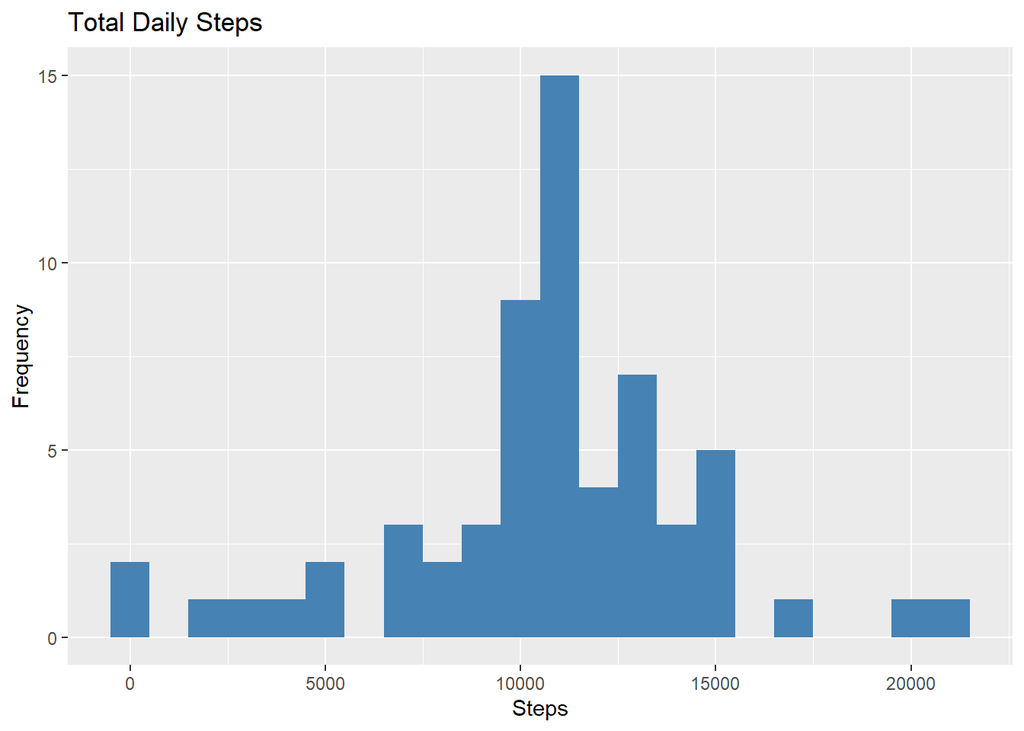

```r
#Plot using ggplot
ggplot(FullSummedDataByDay, aes(x = totalsteps)) +
geom_histogram(fill = "steelblue", binwidth=1000) +
labs(title = "Total Daily Steps", x = "Steps", y = "Frequency")
```

```r
mean(FullSummedDataByDay$totalsteps)
```

```
## [1] 10766.19
```

```r
median(FullSummedDataByDay$totalsteps)
```

```
## [1] 10766.19
```

# 4b) Do these values differ from the estimates from the first part of the assignment?

# Yes, he mean is the same but the median has risen 1.19 steps.

# Original mean

```r
mean(sumdata$totalstep,na.rm = TRUE)
```

```
## [1] 10766.19
```

```r
median(sumdata$totalstep,na.rm = TRUE)
```

```
## [1] 10765
```

# New mean

```r
mean(FullSummedDataByDay$totalsteps)
```

```
## [1] 10766.19
```

```r
median(FullSummedDataByDay$totalsteps)
```

```
## [1] 10766.19
```

# 4c) What is the impact of imputing missing data on the estimates of the total daily number of steps?

# The effect of using mean data per interval as a data impute method for missing values seems to push overall data towards the mean.

# Differences in activity patterns between weekdays and weekends?

```r
activity2$weekday <- weekdays(activity2$date)
activity2$weekend <- ifelse(activity2$weekday == "Saturday" | activity2$weekday == "Sunday","Weekend", "Weekday")
activity2$weekend <- as.factor(activity2$weekend)
head(activity2)
```

```
## # A tibble: 6 x 5
##    steps date       interval weekday weekend
##    <dbl> <date>        <dbl> <chr>   <fct>
## 1 1.72   2012-10-01        0 Monday  Weekday
## 2 0.340  2012-10-01        5 Monday  Weekday
## 3 0.132  2012-10-01       10 Monday  Weekday
## 4 0.151  2012-10-01       15 Monday  Weekday
## 5 0.0755 2012-10-01       20 Monday  Weekday
## 6 2.09   2012-10-01       25 Monday  Weekday
```

```r
meandata2 <- aggregate(activity2$steps,by=list(activity2$weekend,activity2$interval),mean)
head(meandata2)
```

```
##   Group.1 Group.2          x
## 1 Weekday       0 2.25115304
## 2 Weekend       0 0.21462264
## 3 Weekday       5 0.44528302
## 4 Weekend       5 0.04245283
## 5 Weekday      10 0.17316562
## 6 Weekend      10 0.01650943
```

```r
names(meandata2)[1] = "Days"
names(meandata2)[2] = "Interval"
names(meandata2)[3] = "Steps"
head(meandata2)
```

```
##      Days Interval      Steps
## 1 Weekday        0 2.25115304
## 2 Weekend        0 0.21462264
## 3 Weekday        5 0.44528302
## 4 Weekend        5 0.04245283
## 5 Weekday       10 0.17316562
## 6 Weekend       10 0.01650943
```

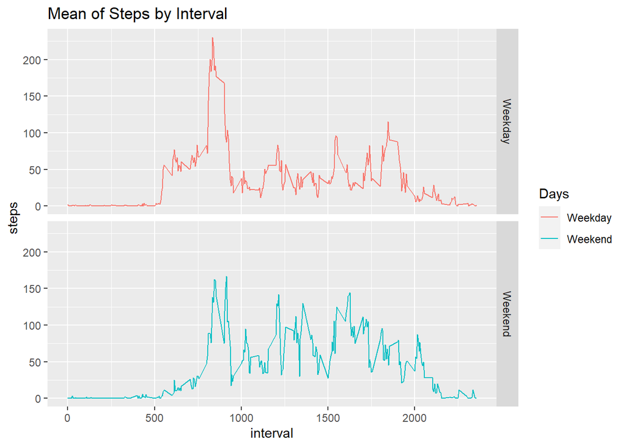

```r
ggplot(meandata2,aes(Interval, Steps, color = Days))+geom_line() +  facet_grid(Days ~.) +labs(title = "Mean of Steps by Interval", x = "interval", y = "steps")
```

# There seems to be variation in the beginning of the day during weekdays, likely due to workplace activities. There seems to be an overall slightly larger incidence of steps during the weekends